# Введение в дисперсионный анализ (ANOVA)

Matvei Slavenko

09.07.2022

# Данные. Генеральная совокупность и рабочая выборка.

Файл `soccer.csv`.

По-прежнему работаем с футболистами: имя, позиция на поле (защитник, форвард, голкипер или полузащитник), гражданство, возраст и рост.

Размер рабочей выборки чуть больше: 150 человек.

```r
soccer_general <- read.csv("soccer.csv", sep=";")[, 2:6] %>%
  mutate(Position = as.factor(Position),
         Nationality = as.factor(Nationality),
         Age = as.numeric(Age),
         Height = as.numeric(Height)) %>%
  filter(Nationality %in% c("Spanish", "Italian", "German", "English", "Argentinian"))
```

```r
set.seed(1)

soccer_wrk <- soccer_general[sample(1:nrow(soccer_general), 150), ] %>%
  mutate(Nationality = factor(Nationality))
```

Дисклеймер: *Не совсем корректно, конечными генеральными совокупностями занимается не классическая статистика, а sample surveys. Но для сегодняшних целей пойдет.*

# В предыдущих сериях

```r
soccer_wrk %>%
  with(
    boxplot(Height ~ Position, col = "cadetblue3", pch = 20,
            ylab = "Height (cm)")
  )
```

[output not shown]

- Попарные сравнения
- Попарных сравнений много, поэтому поправки
- Иными словами: а есть ли связь между позицией и средним ростом футболиста?
  - СВЯЗЬ
  - СРЕДНИМ РОСТОМ

# Условное математическое ожидание aka математический `filter(...) %>% mean`

Для каждого футболиста мы записывали его рост ($Y_i$) и позицию на поле ($D_i$). То есть i-тое наблюдение – это вектор $(Y_i; D_i)$. В прошлый раз мы занимались защитниками (defenders). Средний рост в группе защитников мы можем понимать как средний рост футболиста при условии, что он защитник -> условное среднее, conditional expectation.

Записываем так: $\mathsf{E}[Y|D = \text{Defender}]$.

*УМО – один из способов концептуализировать информацию, которую несет в себе позиция на поле о росте футболиста.*

Условный средний рост футболиста в генеральной совокупности при условии, что он защитник:

```r
soccer_general %>% filter(Position == "Defender") %>% pull(Height) %>% mean
```

```
## [1] 183.586
```

Точечная оценка среднего роста футболиста при условии, что он защитник:

```r
soccer_wrk %>% filter(Position == "Defender") %>% pull(Height) %>% mean
```

```
## [1] 183.2182
```

# В предыдущих сериях: новый взгляд

```r
soccer_wrk %>%
  with(
    boxplot(Height ~ Position, col = "cadetblue3", pch = 20,
            ylab = "Height (cm)")
  )
```

[output not shown]

Обозначим реальные условные средние:
$$\begin{align*}
\mu_{Def} &= \mathsf{E}[Y| D = \text{Defender}] \\
\mu_{For} &= \mathsf{E}[Y| D = \text{Forward}] \\
\mu_{Goal} &= \mathsf{E}[Y| D = \text{Goalkeeper}] \\
\mu_{Mid} &= \mathsf{E}[Y| D = \text{Midfielder}]
\end{align*}$$

# В предыдущих сериях: новый взгляд

```r
soccer_wrk %>%
  with(
    boxplot(Height ~ Position, col = "cadetblue3", pch = 20,
            ylab = "Height (cm)")
  )
```

[output not shown]

Мы тестировали:

$$\begin{gather*}
H_0^1: \mu_{Def} - \mu_{For} = 0 \qquad vs. \qquad H_1^1: \mu_{Def} -
\mu_{For} \neq 0 \\
H_0^2: \mu_{Def} - \mu_{Goal} = 0 \qquad vs. \qquad H_1^2: \mu_{Def} -
\mu_{Goal} \neq 0 \\
\ldots \\
H_0^6: \mu_{Goal} - \mu_{Mid} = 0 \qquad vs. \qquad H_1^6: \mu_{Goal} -
\mu_{Mid} \neq 0
\end{gather*}$$

# В предыдущих сериях: новый взгляд

```r
soccer_wrk %>%
  with(
    boxplot(Height ~ Position, col = "cadetblue3", pch = 20,
            ylab = "Height (cm)")
  )
```

[output not shown]

- Иными словами: а есть ли связь между позицией и средним ростом футболиста?

Это можно сформулировать иначе:
$$\begin{align*}
& H_0\!: \mu_{Def} = \ldots = \mu_{Mid} \\
vs. \\
& H_1\!: \exists i,j: \mu_i \neq \mu_j
\end{align*}$$

Т.е. *“(условный) средний рост футболиста не ассоциирован с его позицией на поле”* или *“позиция игрока на поле не несет информации о среднем росте футболиста”*.

# В предыдущих сериях: новый взгляд

```r
soccer_wrk %>%
  with(
    boxplot(Height ~ Position, col = "cadetblue3", pch = 20,
            ylab = "Height (cm)")
  )
```

[output not shown]

Т.е. *“(условный) средний рост футболиста не ассоциирован с его позицией на поле”* или *“позиция игрока на поле не несет информации о среднем росте футболиста”*.

- Моделированием условного математического ожидания (среднего) занимается регрессия.
- А есть ли связь между позицией и средним ростом футболиста? Такую гипотезу тестирует AN(C)OVA – Analysis of (Co)Variance – Дисперсионный / ковариационный анализ – частный случай регрессионной модели.
- *УМО – один из способов концептуализировать информацию, которую несет в себе позиция на поле о росте футболиста.*
  - Как измерить эту информацию?

# Новый взгляд на среднее и дисперсию

$$\mathsf{E}X := \int_{\mathbb{R}}
xf_X(x)dx \qquad \mathsf{var}X := \mathsf{E}\left(X -
\mathsf{E}X\right)^2$$

$$\overline{X_n} := \frac{1}{n}
\sum_{i=1}^n X_i \qquad S_n^2 := \frac{1}{n-1} \sum_{i=1}^n(X_i -
\overline{X_n})^2$$

- Среднее – это в каком-то смысле оптимальное выражение распределения одним числом.
- Дисперсия – мера (не)оптимальности – мера неопределенности.

$$\mathsf{E}X = \arg \min_{a\in\mathbb{R}}
\mathsf{E}\left(X-a\right)^2$$

- Дисперсия – это сумма квадратов.

# Две модели для среднего

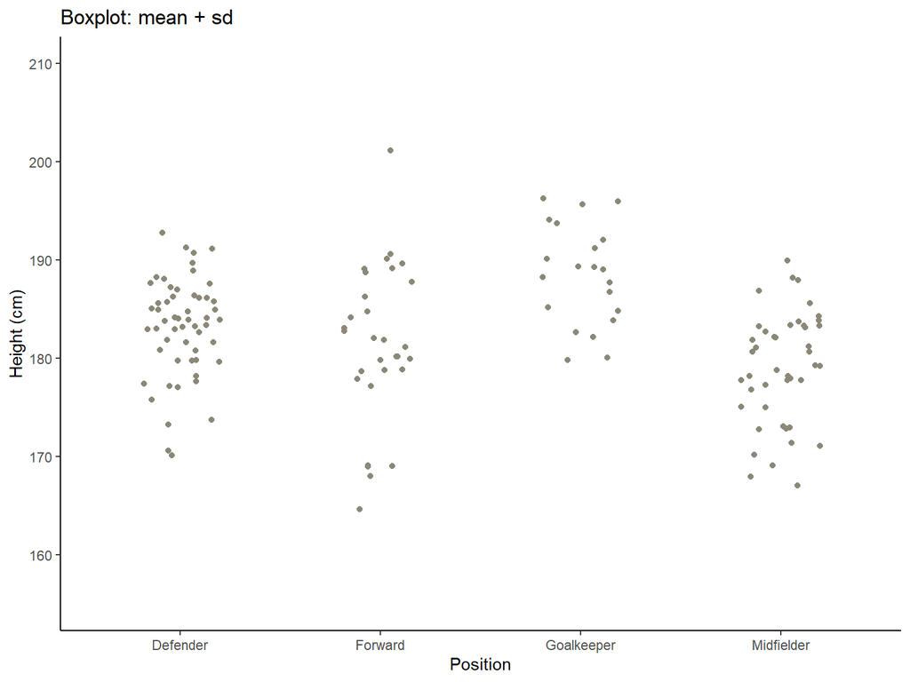

# Две модели для среднего

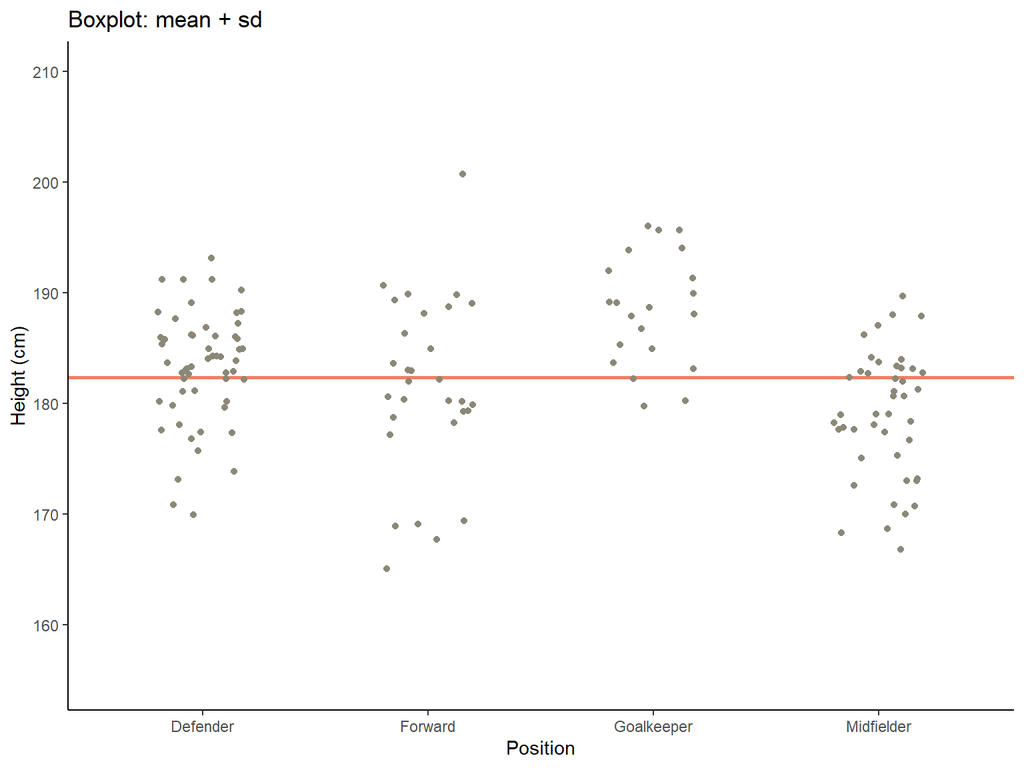

1. Простая модель M0: посчитать среднее по всем футболистам.

# Две модели для среднего

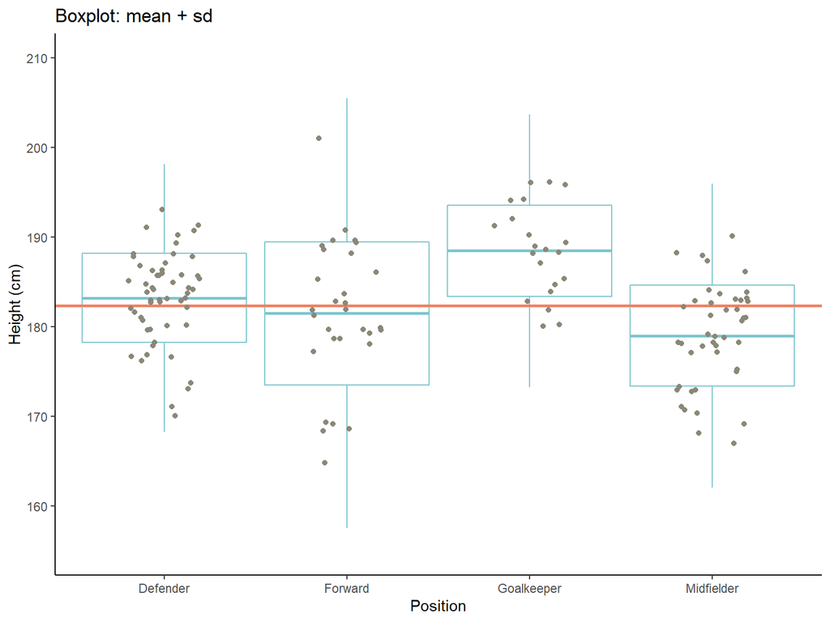

1. Простая модель M0: посчитать среднее по всем футболистам.
2. Более сложная модель М1: посчитать среднее в каждой группе отдельно.

Имеет ли смысл рассматривать более сложную модель, или простая описывает данные “достаточно хорошо”?

# Две модели для среднего

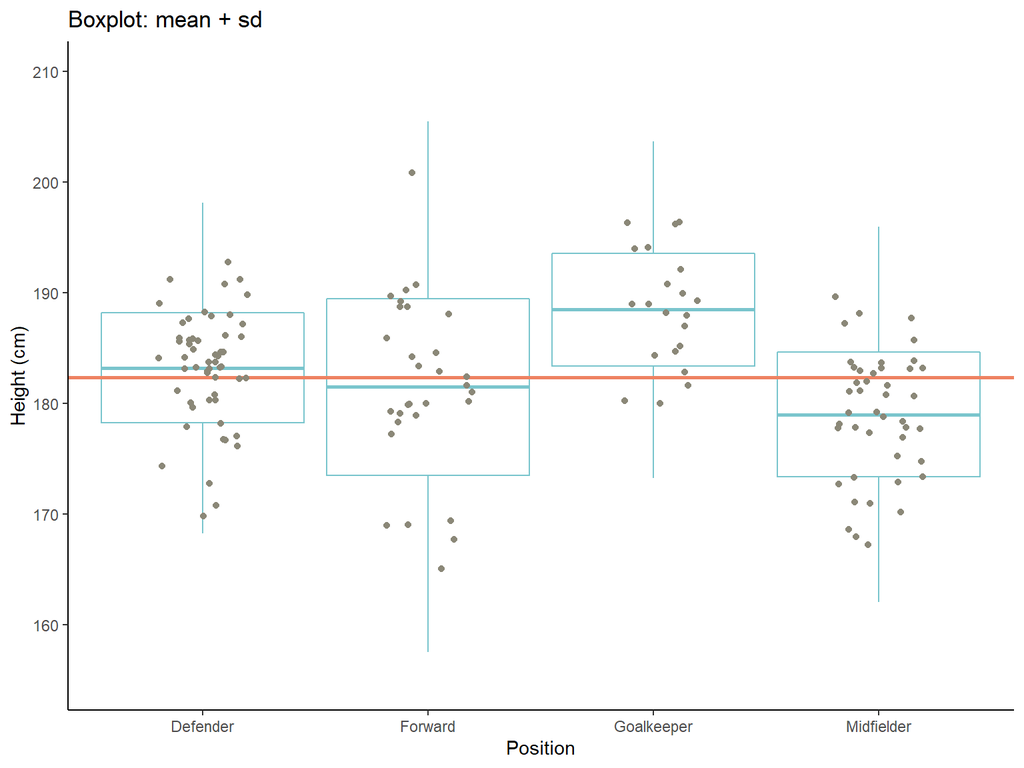

1. Простая модель M0: посчитать среднее по всем футболистам.
2. Более сложная модель М1: посчитать среднее в каждой группе отдельно.

Имеет ли смысл рассматривать более сложную модель, или простая описывает данные “достаточно хорошо”?

$$H_0\!: \mu_{Def} = \ldots = \mu_{Mid}
\quad vs. \quad H_1\!: \exists i,j: \mu_i \neq \mu_j$$

Если справедлива гипотеза, то обе модели описывают одно и то же число! Значит, если справедлива гипотеза, то оценки не должны отличаться слишком сильно. Или: conditioning позицией на поле не должен слишком сильно снижать неопределенность.

# Две модели для среднего

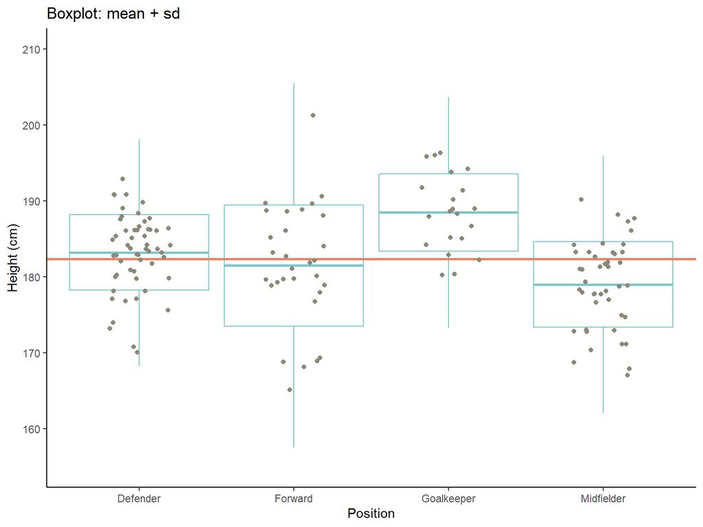

Если справедлива гипотеза, то обе модели описывают одно и то же число! Значит, если справедлива гипотеза, то оценки не должны отличаться слишком сильно. Или: conditioning позицией на поле не должен слишком сильно снижать неопределенность.

**Неопределенность простой модели M0:** дисперсия!

$$S_n^2 := \frac{1}{n-1} \sum_{i=1}^n(Y_i
- \overline{Y_n})^2$$

Ну, или как сумма квадратов (полная, total sum of squares):

$$SS_T := \sum_{i=1}^n(Y_i -
\overline{Y_n})^2$$

# Две модели для среднего

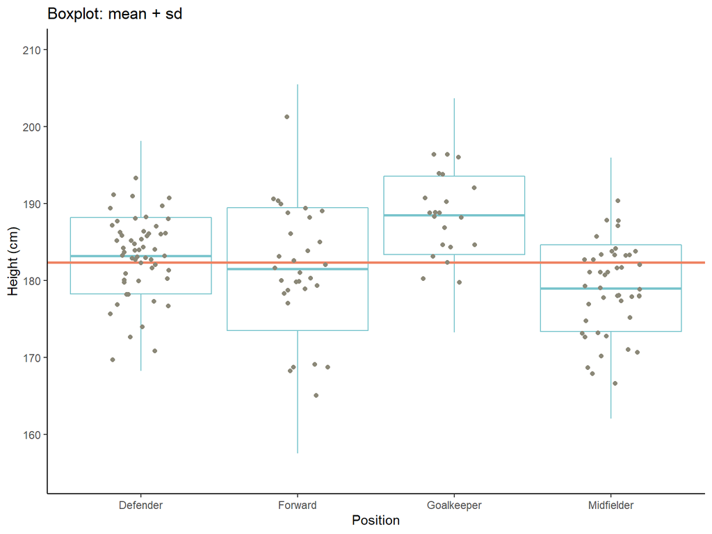

Если справедлива гипотеза, то обе модели описывают одно и то же число! Значит, если справедлива гипотеза, то оценки не должны отличаться слишком сильно. Или: conditioning позицией на поле не должен слишком сильно снижать неопределенность.

**Неопределенность сложной модели M1:** дисперсия!

Ну, почти. Поправим формулу так, чтобы мы учитывали то, что в разных группах, возможно, разные средние. Обозначим среднее, посчитанное в группе $d$, как $\widehat{\mu}_{d}$.

$$S_n^2 := \frac{1}{n-1} \sum_{i=1}^n(Y_i
- \widehat{\mu}_{D_i})^2$$

Ну, или как сумма квадратов (остаточная, residual sum of squares):

$$SS_e := \sum_{i=1}^n(Y_i -
\widehat{\mu}_{D_i})^2$$

# Две модели для среднего

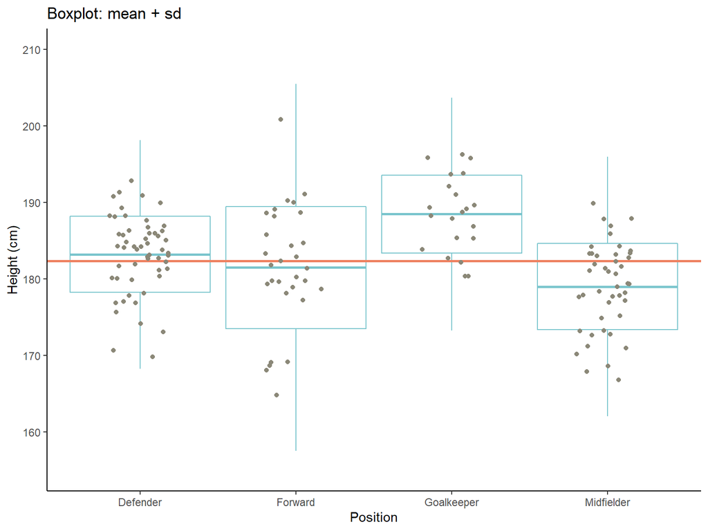

Если справедлива гипотеза, то обе модели описывают одно и то же число! Значит, если справедлива гипотеза, то оценки не должны отличаться слишком сильно. Или: conditioning позицией на поле не должен слишком сильно снижать неопределенность.

**Неопределенность простой модели M0:** полная сумма квадратов $SS_T := \sum_{i=1}^n(Y_i - \overline{Y_n})^2$ **Неопределенность сложной модели M1:** остаточная сумма квадратов $SS_e := \sum_{i=1}^n(Y_i - \widehat{\mu}_{D_i})^2$

Посчитаем, какой процент неопределенности был “объяснен” позицией на поле:

$$\frac{SS_T - SS_e}{SS_T}$$

Кажется, это может быть интересная метрика (спойлер: это же $R^2$)!

# Две модели для среднего. F-test.

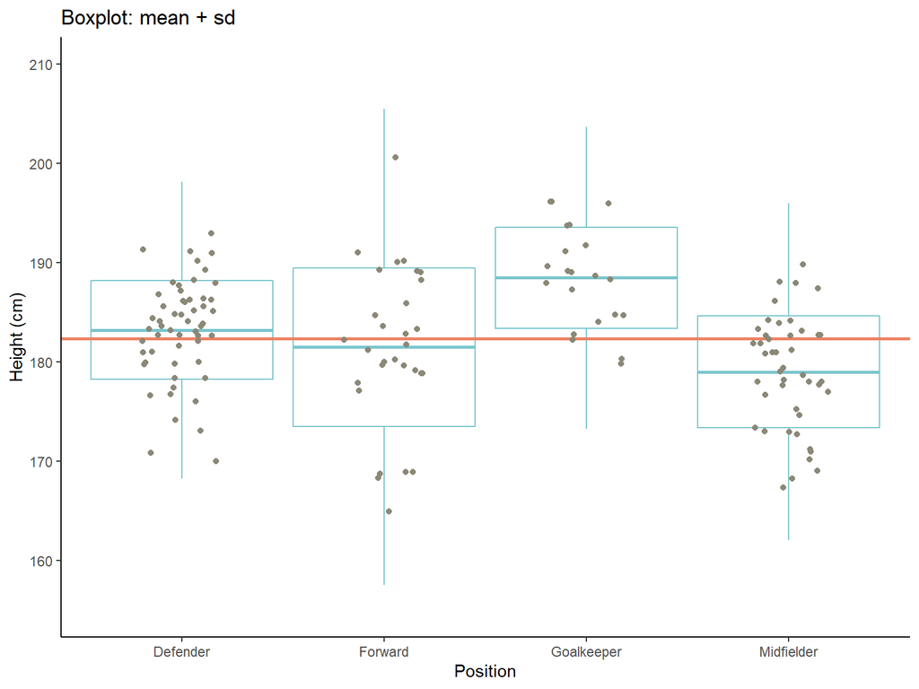

Чтобы тестировать, нам нужно знать распределение тестовой статистики. Используют:

$$F := \frac{\frac{SS_T -
SS_e}{K-1}}{\frac{SS_e}{n-K}}$$

$K$ – количество групп.

$n$ – количество наблюдений.

# Условия для тестирования. F-test.

Условия:

- **Нормальность.** Распределение внутри каждой группы нормально.
- **Гомоскедастичность** ака равенство дисперсий. Дисперсии в каждой группе одинаковы.

Если условия выполнены, то:

$$F := \frac{\frac{SS_T -
SS_e}{K-1}}{\frac{SS_e}{n-K}} \sim F_{K-1, n-K}$$

Тест точный!

# F-test в нашем случае.

Посчитаем сначала руками.

$K=4$, $n=150$.

Посчитаем $SS_T$.

Два варианта:

```r
soccer_wrk %>% pull(Height) %>% var*(nrow(soccer_wrk)-1)
```

```
## [1] 6427.093
```

```r
SST <- with(soccer_wrk, (sum(
  (Height - mean(Height))^2
  )))

SST
```

```
## [1] 6427.093
```

# F-test в нашем случае.

Посчитаем сначала руками.

$K=4$, $n=150$

Посчитаем $SS_e$

```r
SSe <- soccer_wrk %>% group_by(Position) %>% mutate(residuals = Height - mean(Height)) %>%
  with(sum(residuals^2))

SSe
```

```
## [1] 5082.12
```

# F-test в нашем случае.

Посчитаем сначала руками.

$K=4$, $n=150$

Итого:

```r
SST
```

```
## [1] 6427.093
```

```r
SSe
```

```
## [1] 5082.12
```

```r
SST-SSe
```

```
## [1] 1344.973
```

```r
F <- (SST - SSe)/3 / ((SSe)/(150-3))
F
```

```
## [1] 12.96776
```

# F-test в нашем случае.

Итого:

```r
SST
```

```
## [1] 6427.093
```

```r
SSe
```

```
## [1] 5082.12
```

```r
SST-SSe
```

```
## [1] 1344.973
```

```r
F <- (SST - SSe)/3 / ((SSe)/(150-3))
F
```

```
## [1] 12.96776
```

Автоматически:

```r
lm(Height ~ Position, data = soccer_wrk) %>% anova
```

```
## Analysis of Variance Table
##
## Response: Height
##            Df Sum Sq Mean Sq F value    Pr(>F)
## Position    3 1345.0  448.32   12.88 1.635e-07 ***
## Residuals 146 5082.1   34.81
## ---
## Signif. codes:  0 '***' 0.001 '**' 0.01 '*' 0.05 '.' 0.1 ' ' 1
```

# Нарушение условий для тестирования. F-test.

- **Нормальность.** Если данные распределены ненормально, то тест все равно асимптотически консистентный. То есть, работает, если данных достаточно.
- **Гетероскедастичность** ака неравенство дисперсий. И снова Велш (Welch) приходит нам на помощь. F-test Велша работает и в случае негомоскедастичных моделей, при достаточном количестве наблюдений.
  - Второй вариант: сбалансированная (balanced) ANOVA. Если в группах +- одинаковое количество наблюдений, обычная ANOVA работает при достаточном количестве наблюдений.
- Unbalanced ANOVA: лучше всего тест работает тогда, когда в каждой группе +- одинаковое количество наблюдений.

# Нарушение условий для тестирования. F-test.

Стандартная ANOVA:

```r
aov(Height ~ Position, data = soccer_wrk) %>% summary
```

```
##              Df Sum Sq Mean Sq F value   Pr(>F)
## Position      3   1345   448.3   12.88 1.64e-07 ***
## Residuals   146   5082    34.8
## ---
## Signif. codes:  0 '***' 0.001 '**' 0.01 '*' 0.05 '.' 0.1 ' ' 1
```

F-тест Велша:

```r
oneway.test(Height ~ Position, data = soccer_wrk)
```

```
##
##  One-way analysis of means (not assuming equal variances)
##
## data:  Height and Position
## F = 15.44, num df = 3.00, denom df = 62.23, p-value = 1.288e-07
```

# Промежуточные итоги

1. Программистское `... %>% filter(Position = "Defender") %>% pull(Height) %>% mean` соответствует математическому $\mathsf{E}[Y|D = \text{Defender}]$ .
2. Среднее – в определенном смысле лучшее описание распределения одним числом. Дисперсия – мера неопределенности.
3. Пачку попарных t-тестов мы можем переформулировать с помощью одного F-теста. При этом мы теряем информацию о том, какие именно группы отличаются в пользу (надеемся) большей силы теста.
4. Если данных не очень много, нужно проконтролировать нормальность и гомоскедастичность, например, с помощью боксплотов или qq- и scale-location plots.
5. Если данных много, то Велш все спасет.
6. Совсем уж экстремальные выбросы стоит исследовать более подробно.

# Но я хочу доверительные интервалы! Post hoc анализ.

1. Обычно практикуемый подход: запустить F-test, в случае маленького p-value разбираться подробнее (поэтому post hoc).
2. Специальный случай: есть процедуры, контролирующие FWER, более сильные чем Бонферрони, Холм и Ко.
3. Процедур много: Даннетт, Тьюки, доверительные эллипсоиды, дуальные к F-тесту…

Мы остановимся на относительно новой процедуре: процедура Хоторна-Бретца-Вестфала (Hothorn, Bretz, Westfall), основанной на многомерном t-распределении.

Итак, мы хотим доверительные интервалы для разницы роста; попарно сравнить игроков на разных позициях; контролировать FWER.

Стартуем со стандартными предположениями: **нормальность** и **гомоскедастичность**.

# Но я хочу доверительные интервалы! Post hoc анализ.

Еще раз проверим, что **позиция** на поле *ассоциирована* со *средним* **ростом** футболиста.

```r
aov(Height ~ Position, data = soccer_wrk) %>% summary
```

```
##              Df Sum Sq Mean Sq F value   Pr(>F)
## Position      3   1345   448.3   12.88 1.64e-07 ***
## Residuals   146   5082    34.8
## ---
## Signif. codes:  0 '***' 0.001 '**' 0.01 '*' 0.05 '.' 0.1 ' ' 1
```

```r
oneway.test(Height ~ Position, data = soccer_wrk)
```

```
##
##  One-way analysis of means (not assuming equal variances)
##
## data:  Height and Position
## F = 15.44, num df = 3.00, denom df = 62.23, p-value = 1.288e-07
```

# Но я хочу доверительные интервалы! Post hoc анализ.

Можем приступить к post hoc анализу.

```r
library(multcomp)
```

```r
m0 <- lm(Height ~ Position, data = soccer_wrk)
HBW.comp <- m0 %>%  glht(linfct = mcp(Position = "Tukey"))
```

Tukey сигнализирует, что мы хотим сравнить каждую группу с каждой. **Анализ выполняется не методом Тьюки**, а методом Хоторна-Бретца-Вестфалла!

# Но я хочу доверительные интервалы! Post hoc анализ.

Указанные доверительные интервалы и p-values уже рассчитаны с учетом необходимости контролировать FWER.

```r
HBW.comp %>% summary()
```

```
##
##   Simultaneous Tests for General Linear Hypotheses
##
## Multiple Comparisons of Means: Tukey Contrasts
##
##
## Fit: lm(formula = Height ~ Position, data = soccer_wrk)
##
## Linear Hypotheses:
##                              Estimate Std. Error t value Pr(>|t|)
## Forward - Defender == 0        -1.718      1.339  -1.283   0.5714
## Goalkeeper - Defender == 0      5.258      1.513   3.474   0.0037 **
## Midfielder - Defender == 0     -4.218      1.193  -3.535   0.0028 **
## Goalkeeper - Forward == 0       6.976      1.679   4.156   <0.001 ***
## Midfielder - Forward == 0      -2.500      1.397  -1.790   0.2791
## Midfielder - Goalkeeper == 0   -9.476      1.565  -6.056   <0.001 ***
## ---
## Signif. codes:  0 '***' 0.001 '**' 0.01 '*' 0.05 '.' 0.1 ' ' 1
## (Adjusted p values reported -- single-step method)
```

# Но я хочу доверительные интервалы! Post hoc анализ.

Указанные доверительные интервалы и p-values уже рассчитаны с учетом необходимости контролировать FWER.

```r
HBW.comp %>% confint()
```

```
##
##   Simultaneous Confidence Intervals
##
## Multiple Comparisons of Means: Tukey Contrasts
##
##
## Fit: lm(formula = Height ~ Position, data = soccer_wrk)
##
## Quantile = 2.5919
## 95% family-wise confidence level
##
##
## Linear Hypotheses:
##                              Estimate lwr      upr
## Forward - Defender == 0       -1.7182  -5.1890   1.7526
## Goalkeeper - Defender == 0     5.2580   1.3354   9.1807
## Midfielder - Defender == 0    -4.2182  -7.3111  -1.1252
## Goalkeeper - Forward == 0      6.9762   2.6253  11.3271
## Midfielder - Forward == 0     -2.5000  -6.1207   1.1207
## Midfielder - Goalkeeper == 0  -9.4762 -13.5321  -5.4203
```

# Но я хочу доверительные интервалы! Post hoc анализ.

Красивые картиночки работают “из коробки”.

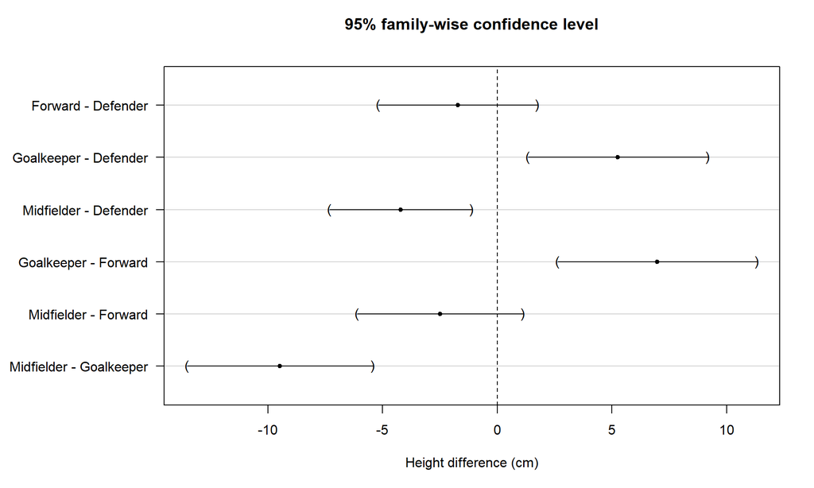

```r
par(mar = c(5, 10, 4, 2)+0.1)
HBW.comp %>% plot(xlab = "Height difference (cm)")
```

```r
par(mar = c(5, 10, 4, 2)+0.1)
```

# Но я хочу доверительные интервалы! Post hoc анализ.

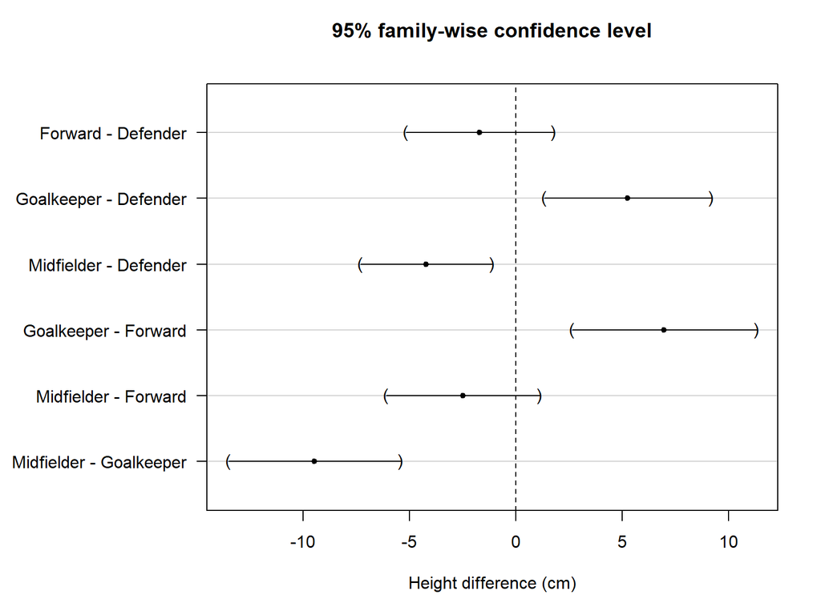

В случае, если соблюдены условия **нормальности** и **гомоскедастичности**, метод точный, т.е. работает и для малых выборок. Метод использует квантили многомерного t-распределения, которые считаются методом Монте-Карло. Если нужна 100% воспроизводимость, не забудьте использовать `set.seed`!

Это очень гибкий метод: можно не только попарно сравнивать группы между собой, можно тестировать любые наборы линейных гипотез. К сожалению, это за рамками сегодняшнего занятия.

Нарушение условий использования:

1. Если нарушено условие **нормальности**, то дополнительных телодвижений делать не нужно: для достаточно больших выборок метод работает (асимптотическая консистентность).
2. Если вдобавок нарушено условие **гомоскедастичности**, то нужно кое-что поправить.

# Но я хочу доверительные интервалы! Post hoc анализ для гетероскедастичных данных.

В случае гетероскедастичных данных необходимо “руками” оценить матрицу вариации-ковариации. Для этого используем библиотеку `sandwich`.

```r
library(sandwich)

HBW.comp.hetero <- m0 %>%  glht(linfct = mcp(Position = "Tukey"),
                                vcov = vcovHC(m0, type = "HC4"))
```

```r
HBW.comp %>% summary
```

```
##
##   Simultaneous Tests for General Linear Hypotheses
##
## Multiple Comparisons of Means: Tukey Contrasts
##
##
## Fit: lm(formula = Height ~ Position, data = soccer_wrk)
##
## Linear Hypotheses:
##                              Estimate Std. Error t value Pr(>|t|)
## Forward - Defender == 0        -1.718      1.339  -1.283  0.57141
## Goalkeeper - Defender == 0      5.258      1.513   3.474  0.00387 **
## Midfielder - Defender == 0     -4.218      1.193  -3.535  0.00304 **
## Goalkeeper - Forward == 0       6.976      1.679   4.156  < 0.001 ***
## Midfielder - Forward == 0      -2.500      1.397  -1.790  0.27914
## Midfielder - Goalkeeper == 0   -9.476      1.565  -6.056  < 0.001 ***
## ---
## Signif. codes:  0 '***' 0.001 '**' 0.01 '*' 0.05 '.' 0.1 ' ' 1
## (Adjusted p values reported -- single-step method)
```

```r
HBW.comp.hetero %>% summary
```

```
##
##   Simultaneous Tests for General Linear Hypotheses
##
## Multiple Comparisons of Means: Tukey Contrasts
##
##
## Fit: lm(formula = Height ~ Position, data = soccer_wrk)
##
## Linear Hypotheses:
##                              Estimate Std. Error t value Pr(>|t|)
## Forward - Defender == 0        -1.718      1.612  -1.066  0.70338
## Goalkeeper - Defender == 0      5.258      1.313   4.006  < 0.001 ***
## Midfielder - Defender == 0     -4.218      1.083  -3.896  < 0.001 ***
## Goalkeeper - Forward == 0       6.976      1.850   3.770  0.00123 **
## Midfielder - Forward == 0      -2.500      1.695  -1.475  0.44605
## Midfielder - Goalkeeper == 0   -9.476      1.414  -6.703  < 0.001 ***
## ---
## Signif. codes:  0 '***' 0.001 '**' 0.01 '*' 0.05 '.' 0.1 ' ' 1
## (Adjusted p values reported -- single-step method)
```

# Но я хочу доверительные интервалы! Post hoc анализ для гетероскедастичных данных.

В случае гетероскедастичных данных необходимо “руками” оценить матрицу вариации-ковариации. Для этого используем библиотеку `sandwich`.

```r
library(sandwich)

HBW.comp.hetero <- m0 %>%  glht(linfct = mcp(Position = "Tukey"),
                                vcov = vcovHC(m0, type = "HC4"))
```

```r
HBW.comp %>% confint
```

```
##
##   Simultaneous Confidence Intervals
##
## Multiple Comparisons of Means: Tukey Contrasts
##
##
## Fit: lm(formula = Height ~ Position, data = soccer_wrk)
##
## Quantile = 2.5904
## 95% family-wise confidence level
##
##
## Linear Hypotheses:
##                              Estimate lwr      upr
## Forward - Defender == 0       -1.7182  -5.1870   1.7506
## Goalkeeper - Defender == 0     5.2580   1.3376   9.1784
## Midfielder - Defender == 0    -4.2182  -7.3094  -1.1270
## Goalkeeper - Forward == 0      6.9762   2.6278  11.3246
## Midfielder - Forward == 0     -2.5000  -6.1186   1.1186
## Midfielder - Goalkeeper == 0  -9.4762 -13.5297  -5.4226
```

```r
HBW.comp.hetero %>% confint
```

```
##
##   Simultaneous Confidence Intervals
##
## Multiple Comparisons of Means: Tukey Contrasts
##
##
## Fit: lm(formula = Height ~ Position, data = soccer_wrk)
##
## Quantile = 2.583
## 95% family-wise confidence level
##
##
## Linear Hypotheses:
##                              Estimate lwr      upr
## Forward - Defender == 0       -1.7182  -5.8808   2.4444
## Goalkeeper - Defender == 0     5.2580   1.8674   8.6486
## Midfielder - Defender == 0    -4.2182  -7.0147  -1.4217
## Goalkeeper - Forward == 0      6.9762   2.1970  11.7554
## Midfielder - Forward == 0     -2.5000  -6.8778   1.8778
## Midfielder - Goalkeeper == 0  -9.4762 -13.1278  -5.8246
```

# Но я хочу доверительные интервалы! Post hoc анализ для гетероскедастичных данных.

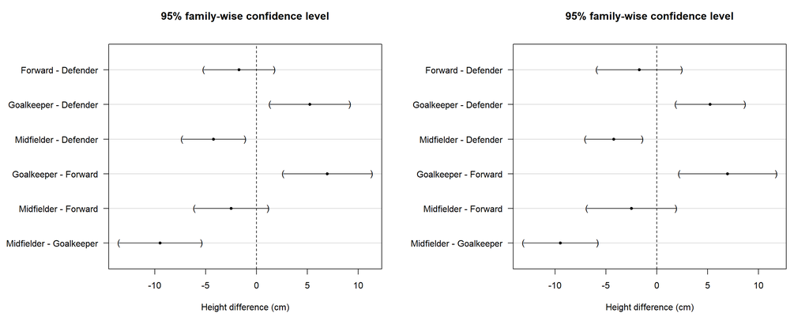

```r
par(mar = c(5, 10, 4, 2)+0.1, mfrow = c(1, 2))
HBW.comp %>% plot(xlab = "Height difference (cm)")
HBW.comp.hetero %>% plot(xlab = "Height difference (cm)")
```

```r
par(mar = c(5, 10, 4, 2)+0.1)
```

# Но я хочу доверительные интервалы! Post hoc анализ для гетероскедастичных данных.

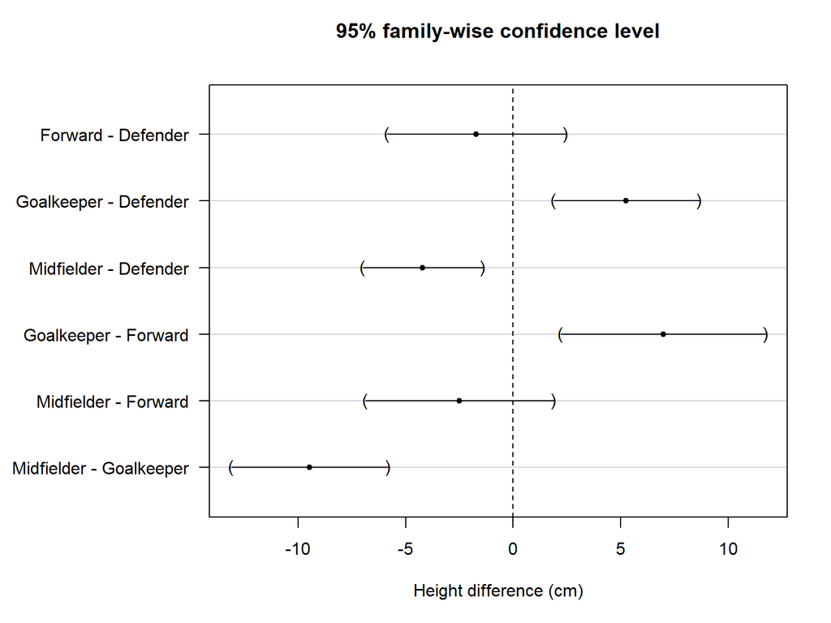

Для того, чтобы справиться с гетероскедастичностью, мы использовали так называемый sandwich estimator.

**Внимание:** сендвичи имеют обыкновение сходиться к реальной дисперсии снизу. На маленькой выборке риск ошибки первого рода повышен!

# Что дальше?

1. Two-way ANOVA, AN(C)OVA и иже с ними – все это частный случай линейной регрессии.
2. А если я знаю, что в группах данные распределены не нормально, а экспоненциально? Без паники, вам на помощь идут обобщенные линейные модели (generalised linear models – GLM).
3. А если у меня зависимые данные (панельные, лонгитудинальные…)? Смешанные модели (Linear Mixed Models) и/или обобщенные оценочные уравнения (Generalized Estimating Equations – GEE).

# Литература

1. Монументальный труд Арношта Комарка [Linear Regression Course Notes](https://www2.karlin.mff.cuni.cz/~komarek/vyuka/2020_21/nmsa407/2021-NMSA407-notes.pdf)
2. Продолжение, касающееся GLM и частично GEE/LMM: [Advanced Regression Models Course Notes](https://www2.karlin.mff.cuni.cz/~kulich/vyuka/pokreg/doc/advreg_notes_ext_220218.pdf) авторства Михала Кулиха.